# Airbnb Popularity Prediction Model

1. Introduction
2. Data splitting
3. EDA
4. Feature engineering
5. Preprocessing and transformations
6. Baseline model
7. Linear models
8. Different models
9. Feature selection
10. Hyperparameter optimization
11. Interpretation and feature importances
12. Results on the test set
13. Summary of results

## Imports

```python
import matplotlib.pyplot as plt
import numpy as np
import pandas as pd
```

```python
import os
import warnings
from pathlib import Path

# Use a logical-CPU budget instead of loky's unavailable Windows core probe.
# Set this before importing joblib/scikit-learn or starting worker processes.
os.environ['LOKY_MAX_CPU_COUNT'] = str(os.cpu_count() or 1)
os.environ['PYTHONWARNINGS'] = 'ignore'
warnings.filterwarnings('ignore')

import joblib
import seaborn as sns
from IPython.display import Markdown, display
from sklearn.base import clone
from sklearn.compose import make_column_transformer
from sklearn.dummy import DummyRegressor
from sklearn.ensemble import RandomForestRegressor
from sklearn.feature_selection import RFECV
from sklearn.impute import SimpleImputer
from sklearn.linear_model import Ridge
from sklearn.metrics import mean_squared_error, r2_score, mean_absolute_error
from sklearn.model_selection import RandomizedSearchCV, cross_validate, train_test_split
from sklearn.pipeline import Pipeline, make_pipeline
from sklearn.preprocessing import OneHotEncoder, StandardScaler
from sklearn.tree import DecisionTreeRegressor
from lightgbm import LGBMRegressor
from model_utils import ListingFeatures

SEED = 123
CV_FOLDS = 5  # Integer CV uses fixed, unshuffled folds for regression.
CHECKPOINT_DIR = Path('artifacts')
CHECKPOINT_DIR.mkdir(exist_ok=True)

def make_lgbm():
    return LGBMRegressor(random_state=SEED, n_jobs=1, verbose=-1,
                         deterministic=True, force_col_wise=True)
```

```python
import subprocess
import sys

installation = subprocess.run(
    [sys.executable, '-m', 'pip', 'install', '--disable-pip-version-check',
     'kagglehub[pandas-datasets]'],
    capture_output=True, text=True,
)
if installation.returncode != 0:
    print(installation.stdout)
    print(installation.stderr)
    installation.check_returncode()
else:
    print('KaggleHub is successfully installed and ready to use.')
```

```
KaggleHub is successfully installed and ready to use.
```

## 1. Introduction

This project uses the [2019 New York City Airbnb dataset](https://www.kaggle.com/datasets/dgomonov/new-york-city-airbnb-open-data) to predict **reviews per month**, a numerical proxy for listing popularity. Price is an input, not the prediction target.

The analysis evaluates held-out listings from one historical snapshot. It does not establish future demand, bookings, occupancy, revenue, or performance for newly posted listings. Listings with missing review rates are excluded rather than assigned invented target values.

The workflow explores training data, constructs listing features, compares regression models, evaluates RFECV, tunes hyperparameters, and explains the selected LightGBM model with SHAP. Neighborhood review totals are learned within each training partition; validation and test review counts do not enter those totals.

```python
#Read the dataframe

import kagglehub
from kagglehub import KaggleDatasetAdapter

df = kagglehub.dataset_load(
    KaggleDatasetAdapter.PANDAS,
    "dgomonov/new-york-city-airbnb-open-data/versions/3",
    "AB_NYC_2019.csv",
    pandas_kwargs={
        "index_col": 0,
        "compression": "zip",
    },
)

df.head()
```

| id | name | host_id | host_name | neighbourhood_group | neighbourhood | latitude | longitude | room_type | price | minimum_nights | number_of_reviews | last_review | reviews_per_month | calculated_host_listings_count | availability_365 |
| --- | --- | --- | --- | --- | --- | --- | --- | --- | --- | --- | --- | --- | --- | --- | --- |
| 2539 | Clean & quiet apt home by the park | 2787 | John | Brooklyn | Kensington | 40.64749 | -73.97237 | Private room | 149 | 1 | 9 | 2018-10-19 | 0.21 | 6 | 365 |
| 2595 | Skylit Midtown Castle | 2845 | Jennifer | Manhattan | Midtown | 40.75362 | -73.98377 | Entire home/apt | 225 | 1 | 45 | 2019-05-21 | 0.38 | 2 | 355 |
| 3647 | THE VILLAGE OF HARLEM....NEW YORK ! | 4632 | Elisabeth | Manhattan | Harlem | 40.80902 | -73.94190 | Private room | 150 | 3 | 0 | NaN | NaN | 1 | 365 |
| 3831 | Cozy Entire Floor of Brownstone | 4869 | LisaRoxanne | Brooklyn | Clinton Hill | 40.68514 | -73.95976 | Entire home/apt | 89 | 1 | 270 | 2019-07-05 | 4.64 | 1 | 194 |
| 5022 | Entire Apt: Spacious Studio/Loft by central park | 7192 | Laura | Manhattan | East Harlem | 40.79851 | -73.94399 | Entire home/apt | 80 | 10 | 9 | 2018-11-19 | 0.10 | 1 | 0 |

```python
df.info()
```

```
<class 'pandas.core.frame.DataFrame'>
Index: 48895 entries, 2539 to 36487245
Data columns (total 15 columns):
 #   Column                          Non-Null Count  Dtype
---  ------                          --------------  -----
 0   name                            48879 non-null  object
 1   host_id                         48895 non-null  int64
 2   host_name                       48874 non-null  object
 3   neighbourhood_group             48895 non-null  object
 4   neighbourhood                   48895 non-null  object
 5   latitude                        48895 non-null  float64
 6   longitude                       48895 non-null  float64
 7   room_type                       48895 non-null  object
 8   price                           48895 non-null  int64
 9   minimum_nights                  48895 non-null  int64
 10  number_of_reviews               48895 non-null  int64
 11  last_review                     38843 non-null  object
 12  reviews_per_month               38843 non-null  float64
 13  calculated_host_listings_count  48895 non-null  int64
 14  availability_365                48895 non-null  int64
dtypes: float64(3), int64(6), object(6)
memory usage: 6.0+ MB
```

## 2. Data splitting

Exclude missing targets, then use a fixed 70% training / 30% test split with `random_state=123`. All model choices use training-set cross-validation. The test set is reserved for final evaluation, alongside a predeclared dummy baseline. This is a listing-level random split, not a temporal or host-group split.

```python
# Unknown target values are excluded rather than assumed to be zero.
# This model estimates review rates for listings with an observed review rate.
model_df = df.dropna(subset=['reviews_per_month']).copy()
print(f"Excluded {len(df) - len(model_df):,} listings with missing review rates.")
X = model_df.drop(columns=['reviews_per_month'])
y = model_df['reviews_per_month']
train_df, test_df = train_test_split(model_df, test_size=0.3, random_state=123)
train_df = train_df.copy()
test_df = test_df.copy()
```

```
Excluded 10,052 listings with missing review rates.
```

## 3. EDA

Exploration uses the training set only, so the test set stays untouched until final evaluation. The goals are to check data types and missing values, see how listings are spread across boroughs and room types, spot skewed features and outliers, and look at how review rates vary between groups. These observations guide the preprocessing choices and evaluation metrics used later.

```python
#Exploring types of data, seeing if there is any missing value
train_df.info()
```

```
<class 'pandas.core.frame.DataFrame'>
Index: 27190 entries, 11937647 to 15043788
Data columns (total 15 columns):
 #   Column                          Non-Null Count  Dtype
---  ------                          --------------  -----
 0   name                            27186 non-null  object
 1   host_id                         27190 non-null  int64
 2   host_name                       27177 non-null  object
 3   neighbourhood_group             27190 non-null  object
 4   neighbourhood                   27190 non-null  object
 5   latitude                        27190 non-null  float64
 6   longitude                       27190 non-null  float64
 7   room_type                       27190 non-null  object
 8   price                           27190 non-null  int64
 9   minimum_nights                  27190 non-null  int64
 10  number_of_reviews               27190 non-null  int64
 11  last_review                     27190 non-null  object
 12  reviews_per_month               27190 non-null  float64
 13  calculated_host_listings_count  27190 non-null  int64
 14  availability_365                27190 non-null  int64
dtypes: float64(3), int64(6), object(6)
memory usage: 3.3+ MB
```

```python
#This provides summary statistics (mean, standard deviation, min, max, quartiles) for all variables in the train set. It helps in understanding the distribution of the data.
train_df.describe(include = 'all')
```

|  | name | host_id | host_name | neighbourhood_group | neighbourhood | latitude | longitude | room_type | price | minimum_nights | number_of_reviews | last_review | reviews_per_month | calculated_host_listings_count | availability_365 |
| --- | --- | --- | --- | --- | --- | --- | --- | --- | --- | --- | --- | --- | --- | --- | --- |
| count | 27186 | 2.719000e+04 | 27177 | 27190 | 27190 | 27190.000000 | 27190.000000 | 27190 | 27190.000000 | 27190.000000 | 27190.000000 | 27190 | 27190.000000 | 27190.000000 | 27190.000000 |
| unique | 26874 | NaN | 7955 | 5 | 214 | NaN | NaN | 3 | NaN | NaN | NaN | 1679 | NaN | NaN | NaN |
| top | Home away from home | NaN | Michael | Manhattan | Williamsburg | NaN | NaN | Entire home/apt | NaN | NaN | NaN | 2019-06-23 | NaN | NaN | NaN |
| freq | 9 | NaN | 245 | 11666 | 2222 | NaN | NaN | 14266 | NaN | NaN | NaN | 993 | NaN | NaN | NaN |
| mean | NaN | 6.362771e+07 | NaN | NaN | NaN | 40.728298 | -73.951300 | NaN | 142.948216 | 5.865576 | 29.613829 | NaN | 1.365532 | 5.143104 | 115.335086 |
| std | NaN | 7.549422e+07 | NaN | NaN | NaN | 0.055004 | 0.046682 | NaN | 208.069211 | 17.122889 | 48.895629 | NaN | 1.642444 | 25.967484 | 129.752309 |
| min | NaN | 2.787000e+03 | NaN | NaN | NaN | 40.506410 | -74.244420 | NaN | 0.000000 | 1.000000 | 1.000000 | NaN | 0.010000 | 1.000000 | 0.000000 |
| 25% | NaN | 6.959995e+06 | NaN | NaN | NaN | 40.688763 | -73.982530 | NaN | 69.000000 | 1.000000 | 3.000000 | NaN | 0.190000 | 1.000000 | 0.000000 |
| 50% | NaN | 2.767398e+07 | NaN | NaN | NaN | 40.721710 | -73.954825 | NaN | 104.000000 | 2.000000 | 9.000000 | NaN | 0.720000 | 1.000000 | 56.000000 |
| 75% | NaN | 1.009713e+08 | NaN | NaN | NaN | 40.763000 | -73.935245 | NaN | 170.000000 | 4.000000 | 33.000000 | NaN | 2.000000 | 2.000000 | 231.000000 |
| max | NaN | 2.738417e+08 | NaN | NaN | NaN | 40.913060 | -73.712990 | NaN | 10000.000000 | 1250.000000 | 629.000000 | NaN | 19.750000 | 327.000000 | 365.000000 |

```python
# the count of each category in the 'neighbourhood_group' column. It helps in understanding the distribution  in the dataset and look for class imbalance.
train_df['neighbourhood_group'].value_counts()
```

```
neighbourhood_group
Manhattan        11666
Brooklyn         11505
Queens            3159
Bronx              636
Staten Island      224
Name: count, dtype: int64
```

```python
# the count of each category in the 'room_type' column. It helps in understanding the distribution of room types in the dataset and look for class imbalance.
train_df['room_type'].value_counts()
```

```
room_type
Entire home/apt    14266
Private room       12356
Shared room          568
Name: count, dtype: int64
```

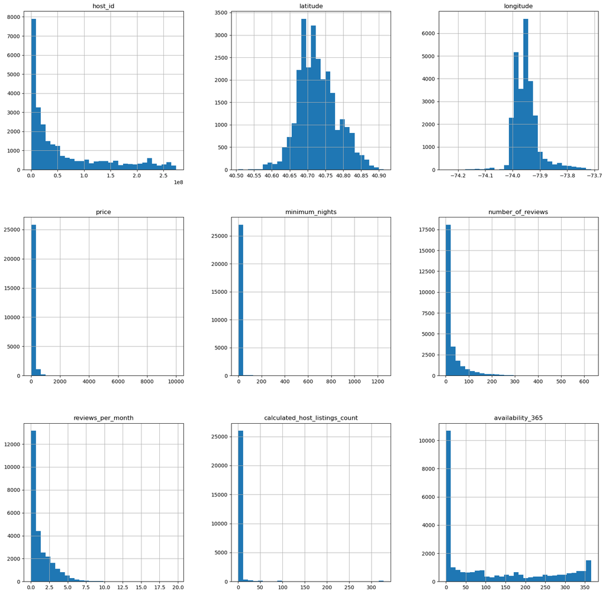

```python
#Histogram to see distribution of the features.

train_df.hist(bins = 30, figsize=(20, 20))
plt.show()
```

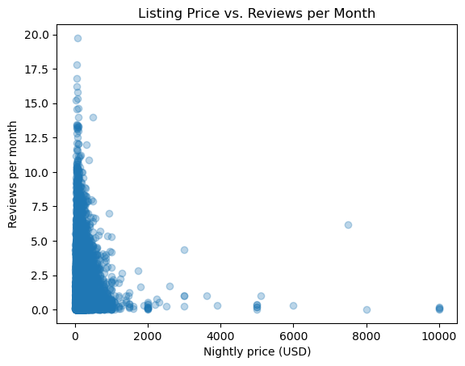

```python
# Relationship between listing price and observed review rate.
plt.scatter(train_df['price'], train_df['reviews_per_month'], alpha=0.3)
plt.xlabel('Nightly price (USD)')
plt.ylabel('Reviews per month')
plt.title('Listing Price vs. Reviews per Month')
plt.show()
```

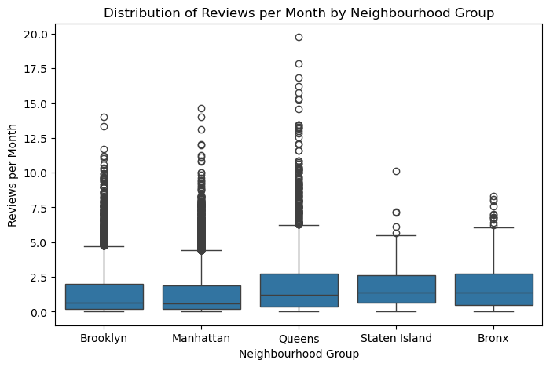

```python
# Boxplot visualizes the relationship between 'neighbourhood_group' and 'reviews_per_month', helping to identify variations in review frequencies across different neighborhoods the room is located.
plt.figure(figsize=(8, 5))
sns.boxplot(x='neighbourhood_group', y='reviews_per_month', data=train_df)
plt.xlabel('Neighbourhood Group')
plt.ylabel('Reviews per Month')
plt.title('Distribution of Reviews per Month by Neighbourhood Group')
plt.show()
```

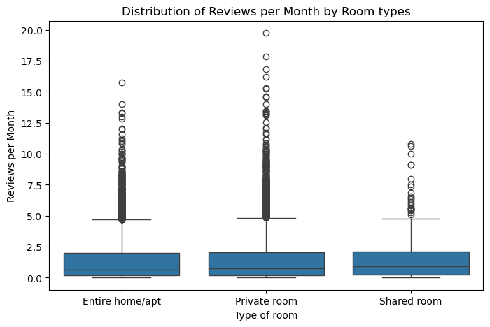

```python
# Boxplot to visualizes the relationship between 'room_type' and 'reviews_per_month', helping to identify variations in review frequencies across different types of rooms.
plt.figure(figsize=(8, 5))
sns.boxplot(x='room_type', y='reviews_per_month', data=train_df)
plt.xlabel('Type of room')
plt.ylabel('Reviews per Month')
plt.title('Distribution of Reviews per Month by Room types')
plt.show()
```

#### Initial observations

Numerical features have different units and ranges, so the Ridge pipelines standardize them. Room types and boroughs have unequal representation; these are predictor categories rather than target classes. The histograms reveal skewed distributions and extreme observations. Boxplots describe variation in review rates across groups without establishing causal effects.

#### Appropriate metrics

We predict `reviews_per_month`, a numerical proxy for popularity.

- **MAE:** average absolute prediction error, in reviews per month.
- **RMSE:** error in reviews per month, with greater weight on large errors.
- **MSE:** average squared prediction error.
- **R-squared:** performance relative to predicting the evaluation set's mean; it can be negative.

MAPE is unsuitable when actual review rates are zero or near zero. Missing targets are excluded before splitting, rather than replaced with zero. This limits the analysis to listings with observed review rates and does not establish performance for new, unreviewed listings.

## 4. Feature engineering

`minimum_stay_price = price × minimum_nights` is the advertised price of a minimum-length stay before fees and discounts. It is not actual host income.

`neighbourhood_popularity` is the total historical reviews of listings in a neighborhood in the training partition. It measures observed review history rather than pure demand and depends on the number of listings. Unseen neighborhoods receive zero historical reviews. The feature transformer is inside every model pipeline, so each validation fold is excluded when its neighborhood totals are learned. It uses review counts only during fitting, never from rows being predicted.

```python
# Preview a stateless listing feature; the pipeline also computes it at prediction time.
train_df['minimum_stay_price'] = train_df['price'] * train_df['minimum_nights']
test_df['minimum_stay_price'] = test_df['price'] * test_df['minimum_nights']
```

```python
# Preview only. CV pipelines fit their own independent feature transformer.
feature_preview = ListingFeatures().fit(train_df)
```

```python
display(feature_preview.transform(train_df)[
    ['neighbourhood', 'minimum_stay_price', 'neighbourhood_popularity']
].head())
```

| id | neighbourhood | minimum_stay_price | neighbourhood_popularity |
| --- | --- | --- | --- |
| 11937647 | Williamsburg | 330 | 60113 |
| 31409612 | Greenpoint | 250 | 14416 |
| 25635216 | Upper West Side | 340 | 24915 |
| 30747515 | Bedford-Stuyvesant | 350 | 79171 |
| 20864878 | Chelsea | 400 | 16556 |

```python
train_df.head(3)
```

| id | name | host_id | host_name | neighbourhood_group | neighbourhood | latitude | longitude | room_type | price | minimum_nights | number_of_reviews | last_review | reviews_per_month | calculated_host_listings_count | availability_365 | minimum_stay_price |
| --- | --- | --- | --- | --- | --- | --- | --- | --- | --- | --- | --- | --- | --- | --- | --- | --- |
| 11937647 | Entire Williamsburg apt. | 12446288 | Micki & Kristian | Brooklyn | Williamsburg | 40.71541 | -73.93748 | Entire home/apt | 110 | 3 | 4 | 2018-05-30 | 0.10 | 1 | 0 | 330 |
| 31409612 | Tremendous Views - Greenpoint | 56061729 | Dennis | Brooklyn | Greenpoint | 40.73421 | -73.95318 | Entire home/apt | 125 | 2 | 8 | 2019-06-10 | 1.37 | 1 | 188 | 250 |
| 25635216 | Clean and Nice Central Park Apt in Lincoln Center | 193127179 | Sagawa | Manhattan | Upper West Side | 40.77640 | -73.98236 | Private room | 85 | 4 | 18 | 2019-05-03 | 1.38 | 1 | 133 | 340 |

```python
test_df.head(3)
```

| id | name | host_id | host_name | neighbourhood_group | neighbourhood | latitude | longitude | room_type | price | minimum_nights | number_of_reviews | last_review | reviews_per_month | calculated_host_listings_count | availability_365 | minimum_stay_price |
| --- | --- | --- | --- | --- | --- | --- | --- | --- | --- | --- | --- | --- | --- | --- | --- | --- |
| 13642568 | Luxe & Spacious Williamsburg Studio | 79167228 | Nate | Brooklyn | Williamsburg | 40.71666 | -73.95447 | Entire home/apt | 105 | 5 | 11 | 2018-08-06 | 0.30 | 1 | 0 | 525 |
| 7516992 | Bedroom in Midtown Apartment | 29544115 | Chisom | Manhattan | Midtown | 40.75737 | -73.96916 | Private room | 70 | 1 | 1 | 2015-08-24 | 0.02 | 1 | 0 | 70 |
| 224510 | BEAUTIFUL APARTMENT, GREAT LOCATION | 991380 | Stefania | Brooklyn | Boerum Hill | 40.68653 | -73.98562 | Entire home/apt | 230 | 4 | 18 | 2018-07-05 | 0.21 | 1 | 0 | 920 |

## 5. Preprocessing and transformations

Each model pipeline learns neighborhood features, median imputation, scaling, and one-hot encoding on its training partition. Unknown categories are ignored by the encoder. Listing names, host identifiers/names, and last-review dates are dropped. Individual `number_of_reviews` is used only to learn training-neighborhood totals and is then dropped; it is not an individual prediction input. The preprocessing fit below is for training-data inspection; cross-validation clones and refits the entire pipeline within each fold.

```python
X_train = train_df.drop(columns = ['reviews_per_month'])
y_train = train_df['reviews_per_month']

X_test = test_df.drop(columns = ['reviews_per_month'])
y_test = test_df['reviews_per_month']

X_train.head()
```

| id | name | host_id | host_name | neighbourhood_group | neighbourhood | latitude | longitude | room_type | price | minimum_nights | number_of_reviews | last_review | calculated_host_listings_count | availability_365 | minimum_stay_price |
| --- | --- | --- | --- | --- | --- | --- | --- | --- | --- | --- | --- | --- | --- | --- | --- |
| 11937647 | Entire Williamsburg apt. | 12446288 | Micki & Kristian | Brooklyn | Williamsburg | 40.71541 | -73.93748 | Entire home/apt | 110 | 3 | 4 | 2018-05-30 | 1 | 0 | 330 |
| 31409612 | Tremendous Views - Greenpoint | 56061729 | Dennis | Brooklyn | Greenpoint | 40.73421 | -73.95318 | Entire home/apt | 125 | 2 | 8 | 2019-06-10 | 1 | 188 | 250 |
| 25635216 | Clean and Nice Central Park Apt in Lincoln Center | 193127179 | Sagawa | Manhattan | Upper West Side | 40.77640 | -73.98236 | Private room | 85 | 4 | 18 | 2019-05-03 | 1 | 133 | 340 |
| 30747515 | Bedstuy-stay | 20043437 | Marianne | Brooklyn | Bedford-Stuyvesant | 40.68581 | -73.95189 | Private room | 35 | 10 | 3 | 2019-05-31 | 1 | 5 | 350 |
| 20864878 | High Line Sun Drenched Home | 13462349 | Elvis | Manhattan | Chelsea | 40.74690 | -73.99494 | Entire home/apt | 200 | 2 | 40 | 2019-06-19 | 1 | 288 | 400 |

```python
X_train.columns
```

```
Index(['name', 'host_id', 'host_name', 'neighbourhood_group', 'neighbourhood',
       'latitude', 'longitude', 'room_type', 'price', 'minimum_nights',
       'number_of_reviews', 'last_review', 'calculated_host_listings_count',
       'availability_365', 'minimum_stay_price'],
      dtype='object')
```

```python
numeric_feats = [
    "latitude",
    "longitude",
    'price',
    "minimum_nights",
    "calculated_host_listings_count",
    "availability_365",
    "minimum_stay_price",
    "neighbourhood_popularity"
] #apply scaling and imputation

categorical_feats = ['neighbourhood_group', 'neighbourhood', "room_type"] # apply one-hot encoding
drop_feats = ['name', 'host_id', 'host_name', 'number_of_reviews', 'last_review'] #drop the features
# passthrough_feats = []
```

```python
columns = make_column_transformer(
    (make_pipeline(SimpleImputer(strategy='median'), StandardScaler()), numeric_feats),
    (OneHotEncoder(handle_unknown='ignore', sparse_output=False), categorical_feats),
    ('drop', drop_feats),
)
ct = Pipeline([('features', ListingFeatures()), ('columns', columns)])
```

```python
ct.fit(X_train)
X_train_transformed  = ct.transform(X_train)
X_test_transformed = ct.transform(X_test)
```

```python
column_names = (
    numeric_feats
    + ct.named_steps['columns'].named_transformers_['onehotencoder']
        .get_feature_names_out().tolist()
)
pd.DataFrame(X_train_transformed, columns=column_names).head()
```

|  | latitude | longitude | price | minimum_nights | calculated_host_listings_count | availability_365 | minimum_stay_price | neighbourhood_popularity | neighbourhood_group_Bronx | neighbourhood_group_Brooklyn | ... | neighbourhood_Williamsbridge | neighbourhood_Williamsburg | neighbourhood_Willowbrook | neighbourhood_Windsor Terrace | neighbourhood_Woodhaven | neighbourhood_Woodlawn | neighbourhood_Woodside | room_type_Entire home/apt | room_type_Private room | room_type_Shared room |
| --- | --- | --- | --- | --- | --- | --- | --- | --- | --- | --- | --- | --- | --- | --- | --- | --- | --- | --- | --- | --- | --- |
| 0 | -0.234313 | 0.296060 | -0.158355 | -0.167357 | -0.159553 | -0.888903 | -0.065330 | 1.429889 | 0.0 | 1.0 | ... | 0.0 | 1.0 | 0.0 | 0.0 | 0.0 | 0.0 | 0.0 | 1.0 | 0.0 | 0.0 |
| 1 | 0.107487 | -0.040264 | -0.086262 | -0.225759 | -0.159553 | 0.560038 | -0.073772 | -0.477825 | 0.0 | 1.0 | ... | 0.0 | 0.0 | 0.0 | 0.0 | 0.0 | 0.0 | 0.0 | 1.0 | 0.0 | 0.0 |
| 2 | 0.874536 | -0.665354 | -0.278510 | -0.108954 | -0.159553 | 0.136146 | -0.064274 | -0.039523 | 0.0 | 0.0 | ... | 0.0 | 0.0 | 0.0 | 0.0 | 0.0 | 0.0 | 0.0 | 0.0 | 1.0 | 0.0 |
| 3 | -0.772465 | -0.012630 | -0.518819 | 0.241460 | -0.159553 | -0.850367 | -0.063219 | 2.225504 | 0.0 | 1.0 | ... | 0.0 | 0.0 | 0.0 | 0.0 | 0.0 | 0.0 | 0.0 | 0.0 | 1.0 | 0.0 |
| 4 | 0.338201 | -0.934841 | 0.274201 | -0.225759 | -0.159553 | 1.330752 | -0.057942 | -0.388486 | 0.0 | 0.0 | ... | 0.0 | 0.0 | 0.0 | 0.0 | 0.0 | 0.0 | 0.0 | 1.0 | 0.0 | 0.0 |

5 rows × 230 columns

```python
# Targets are observed values; do not impute the outcome being predicted.
y_train_transformed = y_train.to_numpy()
y_test_transformed = y_test.to_numpy()
assert np.isfinite(y_train_transformed).all()
assert np.isfinite(y_test_transformed).all()
```

## 6. Baseline model

A dummy regressor that always predicts the training mean sets the baseline every model must beat.

```python
dummy = DummyRegressor()
dummy.fit(X_train_transformed, y_train_transformed)
```

```
DummyRegressor()
```

```python
pd.DataFrame(cross_validate(dummy, X_train_transformed, y_train_transformed, cv=10, return_train_score=True))
```

|  | fit_time | score_time | test_score | train_score |
| --- | --- | --- | --- | --- |
| 0 | 0.017016 | 0.001000 | -1.167858e-07 | 0.0 |
| 1 | 0.016000 | 0.000999 | -5.926877e-04 | 0.0 |
| 2 | 0.018526 | 0.000999 | -6.641477e-04 | 0.0 |
| 3 | 0.015996 | 0.001005 | -1.750686e-03 | 0.0 |
| 4 | 0.017002 | 0.000998 | -4.115215e-04 | 0.0 |
| 5 | 0.015997 | 0.001001 | -4.715488e-04 | 0.0 |
| 6 | 0.016013 | 0.001000 | -3.818223e-04 | 0.0 |
| 7 | 0.014524 | 0.001000 | -5.572702e-04 | 0.0 |
| 8 | 0.014008 | 0.000999 | -7.384986e-04 | 0.0 |
| 9 | 0.015927 | 0.000999 | -1.304838e-03 | 0.0 |

```python
dummy_pred = dummy.predict(X_train_transformed)
#RMSE score
rmse_dummy = np.sqrt(mean_squared_error(y_train_transformed, dummy_pred))

#R^2 score
r2_dummy = r2_score(y_train_transformed, dummy_pred)

#MAE Score
mae_dummy = mean_absolute_error(y_train_transformed, dummy_pred)
```

```python
print("dummy_pred =" + str(dummy_pred))
print("RMSE = "+ str(rmse_dummy))
print("R-Squared = " + str(r2_dummy))
print("MAE = " + str(mae_dummy))
```

```
dummy_pred =[1.36553181 1.36553181 1.36553181 ... 1.36553181 1.36553181 1.36553181]
RMSE = 1.6424134577393583
R-Squared = 0.0
MAE = 1.2282074527378135
```

```python
dummy_pred_test = dummy.predict(X_test_transformed)
#RMSE score
rmse_dummy_test = np.sqrt(mean_squared_error(y_test_transformed, dummy_pred_test))

#R^2 score
r2_dummy_test = r2_score(y_test_transformed, dummy_pred_test)

#MAE Score
mae_dummy_test = mean_absolute_error(y_test_transformed, dummy_pred_test)

print("dummy_pred_test =" + str(dummy_pred_test))
print("RMSE_test = "+ str(rmse_dummy_test))
print("R-Squared_test = " + str(r2_dummy_test))
print("MAE_test = " + str(mae_dummy_test))
```

```
dummy_pred_test =[1.36553181 1.36553181 1.36553181 ... 1.36553181 1.36553181 1.36553181]
RMSE_test = 1.7659796800690788
R-Squared_test = -0.00021070726771688086
MAE_test = 1.2558884715801322
```

```python
display(Markdown(
    f"The dummy regressor predicts the training mean of **{dummy.constant_.item():.3f} "
    f"reviews/month**. Its training MAE is **{mae_dummy:.3f}** and RMSE is "
    f"**{rmse_dummy:.3f}** reviews/month. Its test MAE is **{mae_dummy_test:.3f}**, "
    f"RMSE is **{rmse_dummy_test:.3f}**, and R² is **{r2_dummy_test:.4f}**. "
    "MAE and RMSE are errors in reviews/month, not percentages."
))
```

The dummy regressor predicts the training mean of **1.366 reviews/month**. Its training MAE is **1.228** and RMSE is **1.642** reviews/month. Its test MAE is **1.256**, RMSE is **1.766**, and R² is **-0.0002**. MAE and RMSE are errors in reviews/month, not percentages.

## 7. Linear models

Compare Ridge regularization strengths with five-fold cross-validation. The full feature/preprocessing pipeline is refitted within each fold. The table reports mean training and validation R² and their standard deviations. The highest mean validation R² determines `best_alpha`; this tuning score is not an independent test estimate.

Ridge regression is used as the linear model, since its regularization helps with the many one-hot encoded neighbourhood features.

```python
scores_dict = {
    "alpha": 10.0 ** np.arange(-4, 6, 1),
    "mean_train_scores": list(),
    "mean_cv_scores": list(),
    "std_train_scores": list(),
    "std_cv_scores": list(),
}
for alpha in scores_dict["alpha"]:
    pipe_ridge = make_pipeline(ct, Ridge(alpha=alpha))
    scores = cross_validate(pipe_ridge, X_train, y_train_transformed, return_train_score=True)
    scores_dict["mean_train_scores"].append(scores["train_score"].mean())
    scores_dict["mean_cv_scores"].append(scores["test_score"].mean())
    scores_dict["std_train_scores"].append(scores["train_score"].std())
    scores_dict["std_cv_scores"].append(scores["test_score"].std())

results_df = pd.DataFrame(scores_dict)
```

```python
results_df
```

|  | alpha | mean_train_scores | mean_cv_scores | std_train_scores | std_cv_scores |
| --- | --- | --- | --- | --- | --- |
| 0 | 0.0001 | 0.124102 | 0.097779 | 0.004193 | 0.021340 |
| 1 | 0.0010 | 0.124102 | 0.097781 | 0.004193 | 0.021341 |
| 2 | 0.0100 | 0.124102 | 0.097808 | 0.004193 | 0.021348 |
| 3 | 0.1000 | 0.124091 | 0.098052 | 0.004195 | 0.021406 |
| 4 | 1.0000 | 0.123645 | 0.099333 | 0.004237 | 0.021479 |
| 5 | 10.0000 | 0.119942 | 0.101154 | 0.004296 | 0.020464 |
| 6 | 100.0000 | 0.107996 | 0.096274 | 0.003891 | 0.019064 |
| 7 | 1000.0000 | 0.089250 | 0.082000 | 0.003659 | 0.017626 |
| 8 | 10000.0000 | 0.070830 | 0.067674 | 0.003214 | 0.008163 |
| 9 | 100000.0000 | 0.026011 | 0.025681 | 0.001063 | 0.001485 |

```python
best_alpha_row = results_df.sort_values(by='mean_cv_scores', ascending = False).iloc[0]
best_alpha = best_alpha_row['alpha']
best_alpha
```

```
10.0
```

```python
display(Markdown(
    f"Ridge selected **alpha={best_alpha:g}** with mean validation R² "
    f"**{best_alpha_row['mean_cv_scores']:.4f}** "
    f"(fold standard deviation **{best_alpha_row['std_cv_scores']:.4f}**). "
    f"Mean training R² is **{best_alpha_row['mean_train_scores']:.4f}**. "
    "The difference describes performance on fitted versus held-out folds."
))
```

Ridge selected **alpha=10** with mean validation R² **0.1012** (fold standard deviation **0.0205**). Mean training R² is **0.1199**. The difference describes performance on fitted versus held-out folds.

## 8. Different models

Compare tree-based and boosted models against the Ridge baseline using the same 5-fold cross-validation.

```python
pipe_lr = make_pipeline(ct, Ridge(alpha=best_alpha))
pipe_dt = make_pipeline(ct, DecisionTreeRegressor(random_state=123))
pipe_rf = make_pipeline(ct, RandomForestRegressor(n_jobs=-1, random_state=123))
pipe_lgbm = make_pipeline(
    ct, make_lgbm()
)

regressors = {
    "linear regression": pipe_lr,
    "decision tree": pipe_dt,
    "random forest": pipe_rf,
    "LightGBM": pipe_lgbm,
}

results= {}

for name, model in regressors.items():
    scores = cross_validate(model, X_train, y_train_transformed, cv=CV_FOLDS, scoring='r2', return_train_score=True, error_score='raise')
    results[name] = {
        'mean_fit_time': (scores["fit_time"].mean()),
        'mean_score_time': (scores["score_time"].mean()),
        'mean_train_scores': (scores["train_score"].mean()),
        'mean_cv_scores': (scores["test_score"].mean())
    }
```

```python
pd.DataFrame(results).T
```

|  | mean_fit_time | mean_score_time | mean_train_scores | mean_cv_scores |
| --- | --- | --- | --- | --- |
| linear regression | 0.145558 | 0.025993 | 0.119942 | 0.101154 |
| decision tree | 1.113095 | 0.026785 | 1.000000 | -0.159463 |
| random forest | 9.382222 | 0.096376 | 0.913319 | 0.378988 |
| LightGBM | 0.381599 | 0.051721 | 0.508939 | 0.401639 |

```python
comparison_df = pd.DataFrame(results).T
leader = comparison_df['mean_cv_scores'].idxmax()
display(Markdown(
    f"Among the Section 8 configurations, **{leader}** has the highest mean "
    f"validation R² (**{comparison_df.loc[leader, 'mean_cv_scores']:.4f}**). "
    "These are cross-validation comparisons, not final test results."
))
for name, row in comparison_df.iterrows():
    gap = row['mean_train_scores'] - row['mean_cv_scores']
    display(Markdown(
        f"- **{name}:** training R² {row['mean_train_scores']:.4f}; "
        f"validation R² {row['mean_cv_scores']:.4f}; train-minus-validation gap "
        f"{gap:.4f}. A positive gap indicates lower held-out performance."
    ))
```

Among the Section 8 configurations, **LightGBM** has the highest mean validation R² (**0.4016**). These are cross-validation comparisons, not final test results.

- **linear regression:** training R² 0.1199; validation R² 0.1012; train-minus-validation gap 0.0188. A positive gap indicates lower held-out performance.

- **decision tree:** training R² 1.0000; validation R² -0.1595; train-minus-validation gap 1.1595. A positive gap indicates lower held-out performance.

- **random forest:** training R² 0.9133; validation R² 0.3790; train-minus-validation gap 0.5343. A positive gap indicates lower held-out performance.

- **LightGBM:** training R² 0.5089; validation R² 0.4016; train-minus-validation gap 0.1073. A positive gap indicates lower held-out performance.

## 9. Feature selection

RFECV ranks transformed features using Ridge. The first fit provides descriptive full-training rankings only; its internal scores are not independent validation estimates. The second experiment evaluates RFECV plus LightGBM using outer five-fold cross-validation. The feature/preprocessing pipeline and selection are refitted without the outer validation rows. Inner RFECV scores guide selection on each outer training partition; only outer scores are reported for comparison. The Ridge alpha was chosen in Section 7, so this remains an exploratory training-set comparison, not a nested evaluation of all tuning decisions. The final LightGBM search is predeclared to use all features.

```python
rfe_cv = RFECV(Ridge(alpha=best_alpha), n_jobs=-1, cv=10, scoring='r2')
rfe_cv.fit(X_train_transformed, y_train_transformed)
joblib.dump(rfe_cv, CHECKPOINT_DIR / 'rfecv_full_training.joblib')
display(Markdown(f"Full-training RFECV retained **{rfe_cv.n_features_}** of **{len(column_names)}** transformed features."))
```

Full-training RFECV retained **216** of **230** transformed features.

```python
pd.DataFrame({'feature': column_names, 'rank': rfe_cv.ranking_,
              'selected': rfe_cv.support_}).sort_values(['rank', 'feature'])
```

|  | feature | rank | selected |
| --- | --- | --- | --- |
| 5 | availability_365 | 1 | True |
| 4 | calculated_host_listings_count | 1 | True |
| 0 | latitude | 1 | True |
| 1 | longitude | 1 | True |
| 3 | minimum_nights | 1 | True |
| ... | ... | ... | ... |
| 199 | neighbourhood_Throgs Neck | 11 | False |
| 167 | neighbourhood_Prospect-Lefferts Gardens | 12 | False |
| 37 | neighbourhood_Brownsville | 13 | False |
| 103 | neighbourhood_Grymes Hill | 14 | False |
| 142 | neighbourhood_Morris Park | 15 | False |

230 rows × 3 columns

```python
rfe_pipe = make_pipeline(
    clone(ct),
    RFECV(Ridge(alpha=best_alpha), n_jobs=-1, cv=5, scoring='r2'),
    make_lgbm(),
)
rfe_scores = cross_validate(
    rfe_pipe, X_train, y_train_transformed, cv=CV_FOLDS,
    scoring='r2', return_train_score=True, error_score='raise',
)
rfe_results = pd.DataFrame(rfe_scores).mean()
joblib.dump(rfe_scores, CHECKPOINT_DIR / 'rfecv_outer_scores.joblib')
rfe_results
```

```
fit_time       20.187641
score_time      0.061978
test_score      0.394889
train_score     0.497561
dtype: float64
```

```python
rfe_delta = rfe_results['test_score'] - results['LightGBM']['mean_cv_scores']
direction = 'higher' if rfe_delta > 0 else ('lower' if rfe_delta < 0 else 'equal')
display(Markdown(
    f"RFECV plus LightGBM has mean outer validation R² **{rfe_results['test_score']:.4f}**, "
    f"versus **{results['LightGBM']['mean_cv_scores']:.4f}** with all features. "
    f"Its mean is **{abs(rfe_delta):.4f} {direction}** "
    "(a descriptive comparison, not a significance test). "
    "The final search uses all features as specified above."
))
```

RFECV plus LightGBM has mean outer validation R² **0.3949**, versus **0.4016** with all features. Its mean is **0.0068 lower** (a descriptive comparison, not a significance test). The final search uses all features as specified above.

## 10. Hyperparameter optimization

For each model, RandomizedSearchCV samples five parameter combinations with seed 123 and evaluates five fixed folds using R². The search fits each complete pipeline independently within its training fold, then refits the best configuration on all training rows. Search workers run in parallel; Random Forest and LightGBM use one thread per fit to avoid competing parallel layers. Scores from parameter selection are tuning estimates; final performance is measured on the held-out test set.

Best fitted pipelines, selected parameters, validation scores, and search tables are saved under `artifacts/` after each model. These checkpoints avoid losing expensive fitted results if the kernel closes. Run the final notebook with the same dataset version and Python/package environment for comparable results.

```python
param_lr = {
    "ridge__alpha": 10.0 ** np.arange(-5, 4, 1),
}
param_dt = {
    "decisiontreeregressor__max_depth": np.arange(1, 20, 4),
}

param_rf = {
    "randomforestregressor__n_estimators": np.arange(1, 500, 100),
    "randomforestregressor__max_depth": np.arange(1, 20, 4),
}

param_lgbm = {
    "lgbmregressor__n_estimators": np.arange(1, 500, 100),
    "lgbmregressor__max_depth": np.arange(1, 20, 4),
    "lgbmregressor__learning_rate": [0.01, 0.1, 0.2],
}

models = {
    "Linear Regression": (pipe_lr, param_lr),
    "Decision Tree": (pipe_dt, param_dt),
    "Random Forest": (pipe_rf, param_rf),
    "LightGBM": (pipe_lgbm, param_lgbm)
}

best_hyperparameters = {}
best_estimators = {}
best_cv_scores = {}
search_results = {}

for model_name, (model, param_grid) in models.items():
    search_model = clone(model)
    if model_name == 'Random Forest':
        search_model.set_params(randomforestregressor__n_jobs=1)
    elif model_name == 'LightGBM':
        search_model.set_params(lgbmregressor__n_jobs=1)

    random_search = RandomizedSearchCV(
        search_model, param_distributions=param_grid,
        n_iter=5, cv=CV_FOLDS, scoring='r2', n_jobs=-1,
        random_state=SEED, error_score='raise',
    )
    random_search.fit(X_train, y_train_transformed)
    best_hyperparameters[model_name] = random_search.best_params_
    best_estimators[model_name] = random_search.best_estimator_
    best_cv_scores[model_name] = random_search.best_score_
    search_results[model_name] = pd.DataFrame(random_search.cv_results_)
    joblib.dump(
        dict(best_estimators=best_estimators, best_hyperparameters=best_hyperparameters,
             best_cv_scores=best_cv_scores, search_results=search_results),
        CHECKPOINT_DIR / 'search_checkpoint.joblib',
    )
```

```python
for model_name, parameters in best_hyperparameters.items():
    print(f"{model_name}: {parameters}")
    print(f"Best mean validation R²: {best_cv_scores[model_name]:.4f}\n")
```

```
Linear Regression: {'ridge__alpha': 10.0}
Best mean validation R²: 0.1012

Decision Tree: {'decisiontreeregressor__max_depth': 9}
Best mean validation R²: 0.3059

Random Forest: {'randomforestregressor__n_estimators': 201, 'randomforestregressor__max_depth': 17}
Best mean validation R²: 0.3867

LightGBM: {'lgbmregressor__n_estimators': 301, 'lgbmregressor__max_depth': 13, 'lgbmregressor__learning_rate': 0.1}
Best mean validation R²: 0.4049
```

```python
chosen_params = best_hyperparameters['LightGBM']
display(Markdown(
    f"The selected LightGBM has **{chosen_params['lgbmregressor__n_estimators']} trees**, "
    f"**maximum depth {chosen_params['lgbmregressor__max_depth']}**, and "
    f"**learning rate {chosen_params['lgbmregressor__learning_rate']:g}**. "
    f"Its best mean validation R² is **{best_cv_scores['LightGBM']:.4f}**. "
    "This exact fitted pipeline is used for SHAP and test evaluation below."
))
```

The selected LightGBM has **301 trees**, **maximum depth 13**, and **learning rate 0.1**. Its best mean validation R² is **0.4049**. This exact fitted pipeline is used for SHAP and test evaluation below.

## 11. Interpretation and feature importances

SHAP explains contributions to the selected LightGBM model's predicted reviews per month. Feature rankings use mean absolute contributions across training listings; direction is shown by signed SHAP values, not the absolute ranking.

```python
import shap

pipe_lgbm = best_estimators['LightGBM']
fitted_preprocessor = pipe_lgbm.named_steps['pipeline']
fitted_columns = fitted_preprocessor.named_steps['columns']
column_names = numeric_feats + fitted_columns.named_transformers_[
    'onehotencoder'].get_feature_names_out().tolist()
X_train_transformed = fitted_preprocessor.transform(X_train)
X_test_transformed = fitted_preprocessor.transform(X_test)
assert X_train_transformed.shape[1] == len(column_names)

lgbm_explainer = shap.TreeExplainer(pipe_lgbm.named_steps['lgbmregressor'])
train_lgbm_shap_values = lgbm_explainer.shap_values(X_train_transformed)
```

```python
train_lgbm_shap_values.shape
```

```
(27190, 230)
```

```python
test_lgbm_shap_values = lgbm_explainer.shap_values(X_test_transformed)
test_lgbm_shap_values.shape
```

```
(11653, 230)
```

```python
# load JS visualization code to notebook
shap.initjs()
```

```python
values = np.abs(train_lgbm_shap_values).mean(
    0
)  # mean absolute SHAP contribution for each feature
df_shap = pd.DataFrame(data=values, index=column_names, columns=["SHAP"]).sort_values(
    by="SHAP", ascending=False
)[:10]
df_shap
```

|  | SHAP |
| --- | --- |
| availability_365 | 0.594651 |
| minimum_nights | 0.357591 |
| minimum_stay_price | 0.119782 |
| room_type_Entire home/apt | 0.108268 |
| longitude | 0.087068 |
| calculated_host_listings_count | 0.073588 |
| latitude | 0.057065 |
| price | 0.054357 |
| neighbourhood_popularity | 0.025448 |
| neighbourhood_Hell's Kitchen | 0.022575 |

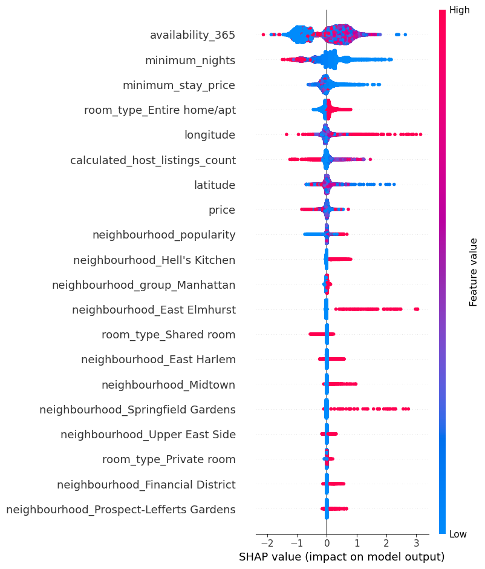

```python
shap.summary_plot(train_lgbm_shap_values, X_train_transformed,
                  feature_names=column_names, show=False)
plt.show()
```

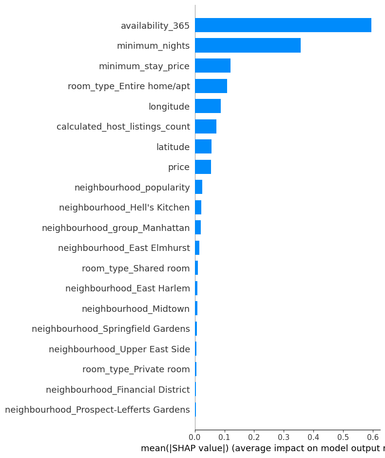

```python
shap.summary_plot(train_lgbm_shap_values, X_train_transformed, feature_names = column_names, plot_type="bar")
```

```python
top_features = ', '.join(f"**{name}** ({value:.3f})" for name, value in df_shap['SHAP'].head(3).items())
display(Markdown(
    f"The three largest mean absolute SHAP contributions are {top_features}, "
    "in reviews/month. These values measure contribution magnitude, not direction. "
    "A feature with high importance may increase some predictions and decrease others. "
    "Associations in these plots do not establish causation."
))
```

The three largest mean absolute SHAP contributions are **availability_365** (0.595), **minimum_nights** (0.358), **minimum_stay_price** (0.120), in reviews/month. These values measure contribution magnitude, not direction. A feature with high importance may increase some predictions and decrease others. Associations in these plots do not establish causation.

## 12. Results on the test set

```python
pipe_lgbm = best_estimators["LightGBM"]
# RandomizedSearchCV has already refitted this pipeline on all training data.
```

```python
preds = pipe_lgbm.predict(X_test)
mae_test = mean_absolute_error(y_test_transformed, preds)

#MSE Score
mse_test = mean_squared_error(y_test_transformed, preds)

#RMSE score
rmse_test = np.sqrt(mean_squared_error(y_test_transformed, preds))

#R^2 score
r2_test = r2_score(y_test_transformed, preds)

test_results_df = pd.DataFrame(
    data = [["Mean Absolute Error",mae_test],["Mean Squared Error",mse_test],["Root Mean Squared Error", rmse_test],["R-Squared Score",r2_test]],
    columns = ["Metric","Score"]
)

test_results_df
```

|  | Metric | Score |
| --- | --- | --- |
| 0 | Mean Absolute Error | 0.861885 |
| 1 | Mean Squared Error | 1.946513 |
| 2 | Root Mean Squared Error | 1.395175 |
| 3 | R-Squared Score | 0.375723 |

```python
display(Markdown(
    f"The selected LightGBM has test MAE **{mae_test:.3f} reviews/month**, "
    f"RMSE **{rmse_test:.3f} reviews/month**, and R² **{r2_test:.4f}**. "
    f"Its best training-CV mean R² was **{best_cv_scores['LightGBM']:.4f}**. "
    "These scores describe different held-out partitions and need not match. "
    "The test set did not select hyperparameters."
))
```

The selected LightGBM has test MAE **0.862 reviews/month**, RMSE **1.395 reviews/month**, and R² **0.3757**. Its best training-CV mean R² was **0.4049**. These scores describe different held-out partitions and need not match. The test set did not select hyperparameters.

```python
# Reuse the selected pipeline's transformations and fitted model; no refitting.
X_train_enc = pd.DataFrame(X_train_transformed, columns=column_names, index=X_train.index)
lgbm_shap = pipe_lgbm.named_steps['lgbmregressor']
X_train_enc.head(3)
```

| id | latitude | longitude | price | minimum_nights | calculated_host_listings_count | availability_365 | minimum_stay_price | neighbourhood_popularity | neighbourhood_group_Bronx | neighbourhood_group_Brooklyn | ... | neighbourhood_Williamsbridge | neighbourhood_Williamsburg | neighbourhood_Willowbrook | neighbourhood_Windsor Terrace | neighbourhood_Woodhaven | neighbourhood_Woodlawn | neighbourhood_Woodside | room_type_Entire home/apt | room_type_Private room | room_type_Shared room |
| --- | --- | --- | --- | --- | --- | --- | --- | --- | --- | --- | --- | --- | --- | --- | --- | --- | --- | --- | --- | --- | --- |
| 11937647 | -0.234313 | 0.296060 | -0.158355 | -0.167357 | -0.159553 | -0.888903 | -0.065330 | 1.429889 | 0.0 | 1.0 | ... | 0.0 | 1.0 | 0.0 | 0.0 | 0.0 | 0.0 | 0.0 | 1.0 | 0.0 | 0.0 |
| 31409612 | 0.107487 | -0.040264 | -0.086262 | -0.225759 | -0.159553 | 0.560038 | -0.073772 | -0.477825 | 0.0 | 1.0 | ... | 0.0 | 0.0 | 0.0 | 0.0 | 0.0 | 0.0 | 0.0 | 1.0 | 0.0 | 0.0 |
| 25635216 | 0.874536 | -0.665354 | -0.278510 | -0.108954 | -0.159553 | 0.136146 | -0.064274 | -0.039523 | 0.0 | 0.0 | ... | 0.0 | 0.0 | 0.0 | 0.0 | 0.0 | 0.0 | 0.0 | 0.0 | 1.0 | 0.0 |

3 rows × 230 columns

```python
X_test_enc = pd.DataFrame(X_test_transformed, columns=column_names, index=X_test.index)
np.testing.assert_allclose(lgbm_shap.predict(X_test_transformed), preds)
X_test_enc.head()
```

| id | latitude | longitude | price | minimum_nights | calculated_host_listings_count | availability_365 | minimum_stay_price | neighbourhood_popularity | neighbourhood_group_Bronx | neighbourhood_group_Brooklyn | ... | neighbourhood_Williamsbridge | neighbourhood_Williamsburg | neighbourhood_Willowbrook | neighbourhood_Windsor Terrace | neighbourhood_Woodhaven | neighbourhood_Woodlawn | neighbourhood_Woodside | room_type_Entire home/apt | room_type_Private room | room_type_Shared room |
| --- | --- | --- | --- | --- | --- | --- | --- | --- | --- | --- | --- | --- | --- | --- | --- | --- | --- | --- | --- | --- | --- |
| 13642568 | -0.211587 | -0.067898 | -0.182386 | -0.050552 | -0.159553 | -0.888903 | -0.044750 | 1.429889 | 0.0 | 1.0 | ... | 0.0 | 1.0 | 0.0 | 0.0 | 0.0 | 0.0 | 0.0 | 1.0 | 0.0 | 0.0 |
| 7516992 | 0.528554 | -0.382585 | -0.350602 | -0.284161 | -0.159553 | -0.888903 | -0.092769 | -0.499241 | 0.0 | 0.0 | ... | 0.0 | 0.0 | 0.0 | 0.0 | 0.0 | 0.0 | 0.0 | 0.0 | 1.0 | 0.0 |
| 224510 | -0.759375 | -0.735190 | 0.418387 | -0.108954 | -0.159553 | -0.888903 | -0.003063 | -0.942469 | 0.0 | 1.0 | ... | 0.0 | 0.0 | 0.0 | 0.0 | 0.0 | 0.0 | 0.0 | 1.0 | 0.0 | 0.0 |
| 26224487 | -1.659690 | -2.676440 | -0.446726 | -0.284161 | -0.121042 | 1.908787 | -0.094880 | -1.050970 | 0.0 | 0.0 | ... | 0.0 | 0.0 | 0.0 | 0.0 | 0.0 | 0.0 | 0.0 | 0.0 | 1.0 | 0.0 |
| 162493 | -0.273947 | -0.131735 | 1.475747 | -0.050552 | -0.159553 | -0.773296 | 0.137300 | 1.429889 | 0.0 | 1.0 | ... | 0.0 | 1.0 | 0.0 | 0.0 | 0.0 | 0.0 | 0.0 | 1.0 | 0.0 | 0.0 |

5 rows × 230 columns

```python
explainer = lgbm_explainer

def explain_listing(position):
    row = X_test_transformed[position:position + 1]
    prediction = float(lgbm_shap.predict(row)[0])
    actual = float(y_test_transformed[position])
    contributions = np.asarray(explainer.shap_values(row)).reshape(-1)
    base = float(np.asarray(explainer.expected_value).item())
    np.testing.assert_allclose(base + contributions.sum(), prediction, rtol=1e-5, atol=1e-5)
    shap.force_plot(base, contributions.reshape(1, -1), row,
                    feature_names=column_names, matplotlib=True,
                    figsize=(18, 4), show=False)
    plt.show()
    positive = np.flatnonzero(contributions > 0)
    negative = np.flatnonzero(contributions < 0)
    positive = positive[np.argsort(contributions[positive])[::-1]][:3]
    negative = negative[np.argsort(contributions[negative])][:3]
    def describe(indices):
        return ', '.join(f"{column_names[j]} ({contributions[j]:+.3f})" for j in indices) or 'none'
    display(Markdown(
        f"**Listing {X_test.index[position]}:** predicted **{prediction:.3f}** reviews/month; "
        f"observed **{actual:.3f}**; baseline **{base:.3f}**. "
        f"The prediction is **{abs(prediction-base):.3f} "
        f"{'above' if prediction >= base else 'below'}** the baseline. "
        f"Largest upward contributions: **{describe(positive)}**. "
        f"Largest downward contributions: **{describe(negative)}**. "
        "Contributions are in reviews/month; numerical feature values in the plot are standardized."
    ))
```

```python
print(f'Predicted reviews/month: {preds[10]:.3f}')
```

```
Predicted reviews/month: 2.293
```

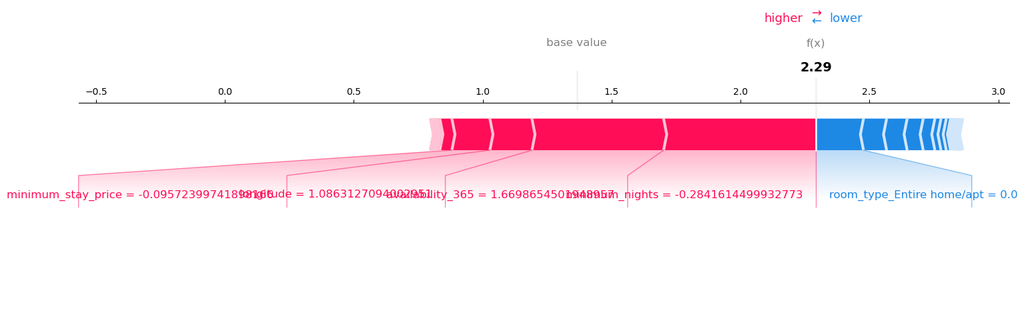

```python
explain_listing(10)
```

[output not shown]

The example above explains the selected model itself. The SHAP contributions sum to its prediction minus the expected prediction; an assertion checks this relationship. These are model explanations, not causal effects.

```python
print(f'Predicted reviews/month: {preds[500]:.3f}')
```

```
Predicted reviews/month: 3.128
```

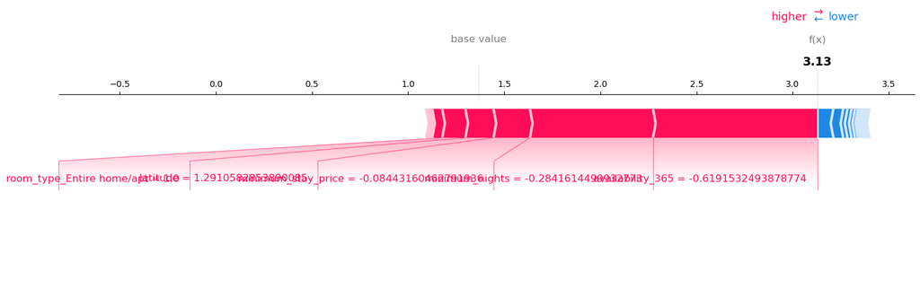

**Listing 31043873:** predicted **3.128** reviews/month; observed **2.430**; baseline **1.366**. The prediction is **1.763 above** the baseline. Largest upward contributions: **availability_365 (+0.855), minimum_nights (+0.640), minimum_stay_price (+0.189)**. Largest downward contributions: **longitude (-0.083), price (-0.051), neighbourhood_East Elmhurst (-0.022)**. Contributions are in reviews/month; numerical feature values in the plot are standardized.

```python
explain_listing(500)
```

The second example uses the same fitted model and preprocessing. Its observed review rate is shown alongside the prediction; the displayed standardized feature values should not be interpreted in their original units.

## 13. Summary of results

```python
test_results_df
```

|  | Metric | Score |
| --- | --- | --- |
| 0 | Mean Absolute Error | 0.861885 |
| 1 | Mean Squared Error | 1.946513 |
| 2 | Root Mean Squared Error | 1.395175 |
| 3 | R-Squared Score | 0.375723 |

```python
mae_change = (mae_dummy_test - mae_test) / mae_dummy_test
rmse_change = (rmse_dummy_test - rmse_test) / rmse_dummy_test
mae_word = 'lower' if mae_change >= 0 else 'higher'
rmse_word = 'lower' if rmse_change >= 0 else 'higher'
r2_description = (
    f"The model explains approximately **{r2_test:.1%}** of test-target variance relative "
    "to a constant prediction of the test mean."
    if r2_test >= 0 else
    "The negative test R² means squared error exceeds that of predicting the test mean."
)
display(Markdown(
    f"The analysis uses **{len(model_df):,}** listings with observed review rates: "
    f"**{len(X_train):,}** for training and **{len(X_test):,}** for testing. "
    f"**{len(df)-len(model_df):,}** listings with missing targets were excluded.\n\n"
    f"The selected LightGBM predicts **reviews per month**, a popularity proxy. "
    f"Test MAE is **{mae_test:.3f}** versus baseline **{mae_dummy_test:.3f}** "
    f"(**{abs(mae_change):.1%} {mae_word}**). Test RMSE is **{rmse_test:.3f}** "
    f"versus baseline **{rmse_dummy_test:.3f}** (**{abs(rmse_change):.1%} {rmse_word}**). "
    f"Test R² is **{r2_test:.4f}**. {r2_description}\n\n"
    "Neighborhood features are learned within training folds. This listing-level random "
    "split of a 2019 snapshot does not establish future forecasting performance, "
    "generalization to unseen hosts, or performance for unreviewed listings. "
    "Reviews are a proxy for popularity, not direct bookings, occupancy, or revenue."
))
joblib.dump(dict(model=pipe_lgbm, test_results=test_results_df, predictions=preds,
                 test_index=X_test.index, feature_names=column_names,
                 best_cv_scores=best_cv_scores), CHECKPOINT_DIR / 'final_results.joblib')
```

The analysis uses **38,843** listings with observed review rates: **27,190** for training and **11,653** for testing. **10,052** listings with missing targets were excluded.

The selected LightGBM predicts **reviews per month**, a popularity proxy. Test MAE is **0.862** versus baseline **1.256** (**31.4% lower**). Test RMSE is **1.395** versus baseline **1.766** (**21.0% lower**). Test R² is **0.3757**. The model explains approximately **37.6%** of test-target variance relative to a constant prediction of the test mean.

Neighborhood features are learned within training folds. This listing-level random split of a 2019 snapshot does not establish future forecasting performance, generalization to unseen hosts, or performance for unreviewed listings. Reviews are a proxy for popularity, not direct bookings, occupancy, or revenue.

```
['artifacts\\final_results.joblib']
```

```python
from importlib.metadata import version
import json
import platform

environment = {name: version(name) for name in
               ['numpy', 'pandas', 'scipy', 'scikit-learn', 'lightgbm', 'shap', 'joblib', 'kagglehub']}
environment.update(python=platform.python_version(), dataset_version=3, seed=SEED)
(CHECKPOINT_DIR / 'environment.json').write_text(json.dumps(environment, indent=2))
print('Models, search results, RFECV outputs, and environment saved in artifacts/.')
```

```
Models, search results, RFECV outputs, and environment saved in artifacts/.
```